# Michelson-Morley

К вопросу об интерпретации результатов эксперимента Майкельсона Морли

А.Ю.Дроздов

Проблема интерпретации результатов эксперимента Майкельсона Морли снимается, если правильно нарисовать ход лучей в интерферометре Майкельсона. Данная информация позаимствованна мною в одном из интернет форумов.

Главное что надо понимать это то что физически луч представляет собой не тонкую линию, а имеет некоторую ширину, в связи с этим, если в теории эфира вертикально направленный (по рисунку) луч сносится эфирным ветром то обратно к полупрозрачному зеркалу он приходит не в ту же самую точку а с некоторым смещением, и далее его интерференция происходит уже с соседней "линией" исходного широкого луча

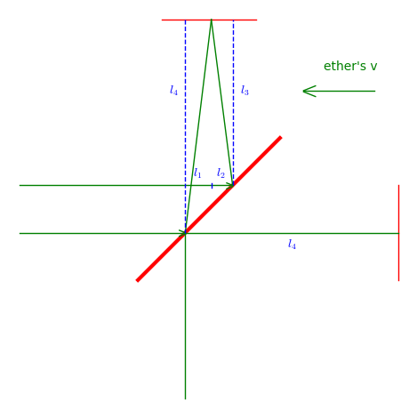

```python
# mirrors
p = line([[5,-3],[11,3]], color = "red", thickness=3)

p += line ([[6,8],[10,8]], color = "red")
p += line ([[16,-3],[16,1]], color = "red")

# incoming light beam
p += line ([[0,1],[9,1]], color = "green")
p += line ([[8.75,1.1],[9,1]], color = "green")
p += line ([[8.75,0.85],[9,0.95]], color = "green")

p += line ([[0,-1],[7,-1]], color = "green")
p += line ([[6.75,-0.9],[7,-1]], color = "green")
p += line ([[6.75,-1.15],[7,-1.05]], color = "green")

# up directed refracted beam
p += line ([[9,1],[8.1,8]], color = "green")

# down directed beam
p += line ([[8.1,8],[7,-1]], color = "green")

# right - left directed beam
p += line ([[7,-1],[16,-1]], color = "green")

# down directed beam
p += line ([[7,-1],[7,-8]], color = "green")

p += text("ether's v", [14, 6], color = "green")
p += line ([[12,5],[15,5]], color = "green")
p += line ([[12,5],[12.5,5.2]], color = "green")
p += line ([[12,4.95],[12.5,4.75]], color = "green")

p += text("$l_2$", [8.5, 1.5])
p += text("$l_1$", [7.5, 1.5])
p += text("$l_4$", [11.5, -1.5])

p += line ([[8.1,1.1],[8.1,0.9]])
# p += line ([[7,1.1],[7,0.9]])

# up directed refracted beam's catet
p += line ([[9,1],[9,8]], linestyle="dashed")
p += text("$l_3$", [9.5, 5])

# down directed beam's catet
p += line ([[7,8],[7,-1]], linestyle="dashed")
p += text("$l_4$", [6.5, 5])

p.show(aspect_ratio = 1, axes=False)
```

```python
from IPython.display import display, Math, Latex

l_1 = var("l_1")
l_2 = var("l_2")
l_3 = var("l_3")
l_4 = var("l_4")

c = var("c")
v = var("v")
```

Рассчитаем время хода луча параллельно скорости эфира. Это время в официальных учебниках рассчитано правильно - с учётом закона сложения скоростей

```python
t_parallel = l_4 / (c - v) + l_4 / (c + v)
```

```python
display(Math(latex(t_parallel)))
```

$$\frac{l_{4}}{c + v} + \frac{l_{4}}{c - v}$$

```python
display(Math(latex(t_parallel.factor())))
```

$$\frac{2 \, c l_{4}}{{\left(c + v\right)} {\left(c - v\right)}}$$

Рассчитаем время хода луча перпендикулярно скорости эфира. Здесь официальные учебники (например, Макс Борн. Эйнштейновская теория относительности) допускают две ошибки:

1) во первых, официально здесь закон сложения скоростей не применяется, а было бы правильно его применять также и здесь (в векторном виде), поскольку он применяется при вычислении времени прохождения луча вдоль скорости эфира и с точки зрения эфирной теории это было бы последовательно

2) в официальных учебниках не учитывается дополнительное расстояние пройденное поперечным лучом возникающее в связи со сносом луча

Учитывая все это находим:

```python
t_perpendicular = (l_1 + l_2) / (c - v) + l_3 / c + l_4 / c
```

```python
display(Math(latex(t_perpendicular)))
```

$$\frac{l_{1} + l_{2}}{c - v} + \frac{l_{3}}{c} + \frac{l_{4}}{c}$$

Исходя из векторного закона сложения скоростей и простых геометрических соотношений находим

```python
eq_l1 = l_1 == v/c*l_4
display(Math(latex(eq_l1)))
```

$$l_{1} = \frac{l_{4} v}{c}$$

```python
eq_l2 = l_2 == v/c*l_3
display(Math(latex(eq_l2)))
```

$$l_{2} = \frac{l_{3} v}{c}$$

```python
eq_l3 = l_1 + l_2 + l_3 == l_4
display(Math(latex(eq_l3)))
```

$$l_{1} + l_{2} + l_{3} = l_{4}$$

Теперь решаем полученную систему уравнений

```python
eq_l4 = eq_l3.subs(eq_l1).subs(eq_l2)
display(Math(latex(eq_l4)))
```

$$l_{3} + \frac{l_{3} v}{c} + \frac{l_{4} v}{c} = l_{4}$$

```python
l3 = solve(eq_l4, l_3)
display(Math(latex(l3)))
```

$$\left[l_{3} = \frac{c l_{4} - l_{4} v}{c + v}\right]$$

И таким образом находим время прохождения перпендикулярного луча

```python
t_perpendicular = t_perpendicular.subs(eq_l1).subs(eq_l2).subs(l3)
```

```python
display(Math(latex(t_perpendicular)))
```

$$\frac{l_{4}}{c} + \frac{\frac{l_{4} v}{c} + \frac{{\left(c l_{4} - l_{4} v\right)} v}{{\left(c + v\right)} c}}{c - v} + \frac{c l_{4} - l_{4} v}{{\left(c + v\right)} c}$$

```python
display(Math(latex(t_perpendicular.full_simplify())))
```

$$\frac{2 \, c l_{4}}{c^{2} - v^{2}}$$

которое в точности соответствует времени прохождения параллельного луча

```python
display(Math(latex(t_parallel.full_simplify())))
```

$$\frac{2 \, c l_{4}}{c^{2} - v^{2}}$$

Таким образом предположение о линейном сокращении размера продольного плеча интерферометра (сокращение Лоренца), сделанное в теории относительности становится излишним. Кроме того отрицательный результат эксперимента Майкельсона Морли при его правильной интерпретации не входит в противоречие с теорией эфирного ветра